# FPET-Style Hierarchical Logistic Growth Model for Modern Contraceptive Prevalence (mCPR): Best-Compromise Variant

### 24.22.2 Weighted SSA region on the S curve, excluding Nigeria and DRC

This replication keeps the same weighting logic and S-curve interpretation, but removes Nigeria and the Democratic Republic of the Congo from the regional aggregation and renormalizes the remaining country weights. It shows how much those two large-population countries drive the weighted SSA regional stage picture.

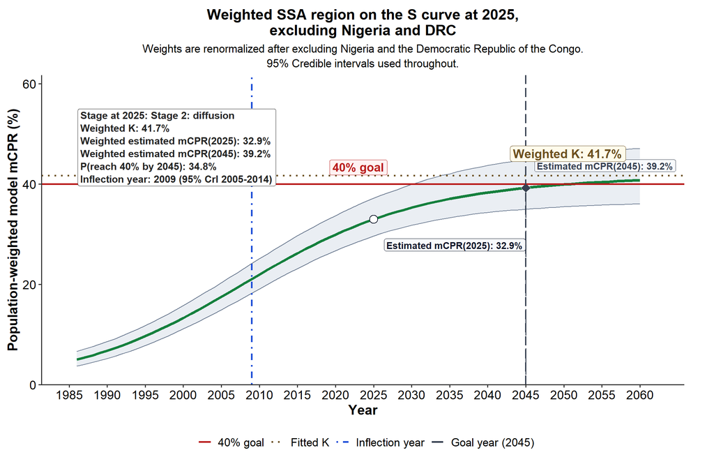

```r
plot_weighted_ssa_stage_view(
  stage_plot_df = ssa_region_stage_plot_excl_ndrc,
  stage_summary_df = ssa_region_stage_summary_excl_ndrc,
  stage_note_text = ssa_region_stage_note_excl_ndrc,
  title_text = "Weighted SSA region on the S curve at 2025,\nexcluding Nigeria and DRC",
  subtitle_text = paste0(
    "Weights are renormalized after excluding Nigeria and the Democratic Republic of the Congo.\n",
    "95% Credible intervals used throughout."
  ),
  k_label_prefix = "Weighted",
  y_axis_label = "Population-weighted model mCPR (%)"
)
```

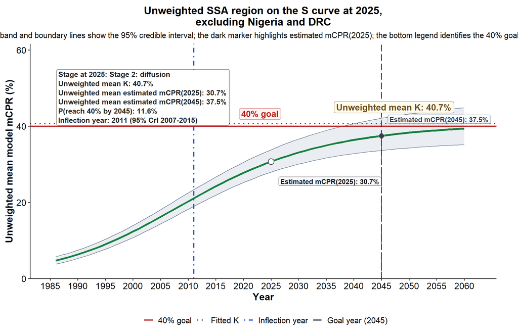

```r
plot_weighted_ssa_stage_view(
  stage_plot_df = ssa_region_stage_plot_excl_ndrc_unweighted,
  stage_summary_df = ssa_region_stage_summary_excl_ndrc_unweighted,
  stage_note_text = ssa_region_stage_note_excl_ndrc_unweighted,
  title_text = "Unweighted SSA region on the S curve at 2025,\nexcluding Nigeria and DRC",
  subtitle_text = paste0("This equal-country version removes Nigeria and the Democratic Republic of the Congo, then averages the remaining country trajectories without population weights. The grey band and boundary lines show the 95% credible interval; the dark marker highlights estimated mCPR(2025); the bottom legend identifies the 40% goal, fitted K, inflection year, and the ", ssa_goal_final_target_year, " goal year; and the top-left box reports the projected level and probability of reaching 40% by ", ssa_goal_final_target_year, ". The projection continues through 2060."),
  k_label_prefix = "Unweighted mean",
  y_axis_label = "Unweighted mean model mCPR (%)"
)
```

### 24.22.3 Weighted priority geographies on the S curve

This version applies the same weighted S-curve logic to the seven priority geographies only: Nigeria, Senegal, Ethiopia, Burkina Faso, Cote d’Ivoire, Kenya, and Niger.

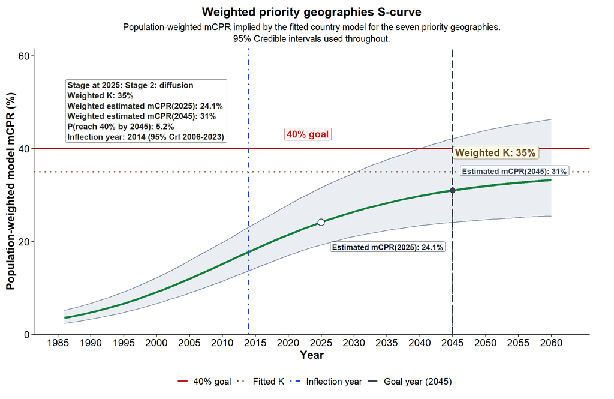

```r
plot_weighted_ssa_stage_view(
  stage_plot_df = ssa_priority_stage_plot,
  stage_summary_df = ssa_priority_stage_summary,
  stage_note_text = ssa_priority_stage_note,
  title_text = "Weighted priority geographies S-curve",
  subtitle_text = paste0(
    "Population-weighted mCPR implied by the fitted country model for the seven priority geographies.\n",
    "95% Credible intervals used throughout."
  ),
  k_label_prefix = "Weighted",
  y_axis_label = "Population-weighted model mCPR (%)"
)
```

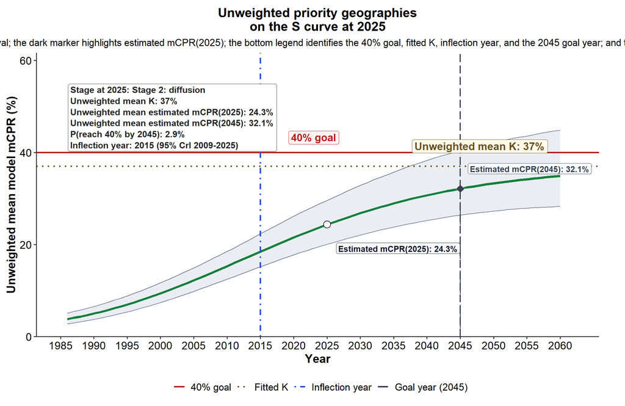

```r
plot_weighted_ssa_stage_view(
  stage_plot_df = ssa_priority_stage_plot_unweighted,
  stage_summary_df = ssa_priority_stage_summary_unweighted,
  stage_note_text = ssa_priority_stage_note_unweighted,
  title_text = "Unweighted priority geographies\non the S curve at 2025",
  subtitle_text = paste0("This is the simple equal-country mean across the seven priority geographies. The grey band and boundary lines show the 95% credible interval; the dark marker highlights estimated mCPR(2025); the bottom legend identifies the 40% goal, fitted K, inflection year, and the ", ssa_goal_final_target_year, " goal year; and the top-left box reports the projected unweighted level and probability of being at or above 40% by ", ssa_goal_final_target_year, ". The projection continues through 2060."),
  k_label_prefix = "Unweighted mean",
  y_axis_label = "Unweighted mean model mCPR (%)"
)
```

### 24.22.4 Weighted priority geographies on the S curve, excluding Nigeria

This replication shows how much Nigeria drives the weighted priority-geography S-curve picture by removing Nigeria and renormalizing the remaining six-country population weights.

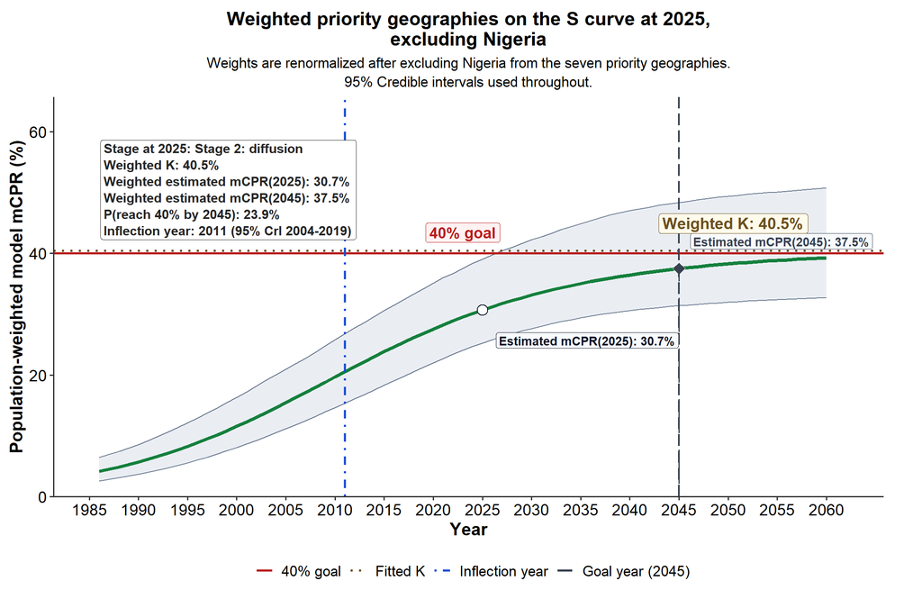

```r
plot_weighted_ssa_stage_view(
  stage_plot_df = ssa_priority_stage_plot_excl_nigeria,
  stage_summary_df = ssa_priority_stage_summary_excl_nigeria,
  stage_note_text = ssa_priority_stage_note_excl_nigeria,
  title_text = "Weighted priority geographies on the S curve at 2025,\nexcluding Nigeria",
  subtitle_text = paste0(
    "Weights are renormalized after excluding Nigeria from the seven priority geographies.\n",
    "95% Credible intervals used throughout."
  ),
  k_label_prefix = "Weighted",
  y_axis_label = "Population-weighted model mCPR (%)"
)
```

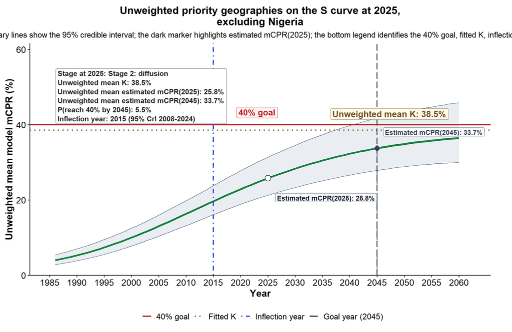

```r
plot_weighted_ssa_stage_view(
  stage_plot_df = ssa_priority_stage_plot_excl_nigeria_unweighted,
  stage_summary_df = ssa_priority_stage_summary_excl_nigeria_unweighted,
  stage_note_text = ssa_priority_stage_note_excl_nigeria_unweighted,
  title_text = "Unweighted priority geographies on the S curve at 2025,\nexcluding Nigeria",
  subtitle_text = paste0("This equal-country version excludes Nigeria and averages the remaining six priority-country trajectories without population weights. The grey band and boundary lines show the 95% credible interval; the dark marker highlights estimated mCPR(2025); the bottom legend identifies the 40% goal, fitted K, inflection year, and the ", ssa_goal_final_target_year, " goal year; and the top-left box reports the projected level and probability of reaching 40% by ", ssa_goal_final_target_year, ". The projection continues through 2060."),
  k_label_prefix = "Unweighted mean",
  y_axis_label = "Unweighted mean model mCPR (%)"
)
```

### 24.22.5 Every SSA country on the S curve

Each panel uses the 2026 S-curve stage classification and shows the country trajectory, fitted `K`, and inflection year directly.

How the 3-stage classification is calculated here: a) we ask where each country sits on its fitted S curve in `2026`, relative to its own fitted ceiling `K` and inflection year; b) `Stage 1: initial` means the country is still in the early part of the transition, well before the steep takeoff phase, and still far below its fitted ceiling; c) `Stage 2: diffusion` means the country is in the middle of the transition, where growth is most active and the curve is moving through its steepest part; d) `Stage 3: plateau` means the country is in the late part of the transition, after the steep growth phase, and is flattening toward its fitted ceiling; e) operationally, we classify countries by how far along the fitted curve they are in `2026`: below about `18%` of fitted `K` is `Stage 1`, roughly `18%` to `82%` of fitted `K` is `Stage 2`, and above about `82%` of fitted `K` is `Stage 3`; f) because this is Bayesian, the model does this across posterior draws, and the stage shown in the figure is the one with the highest posterior probability.

Line guide for the figure: a) the colored line and ribbon show the posterior mean trajectory and 95% credible interval; b) the ochre dotted horizontal line marks fitted `K`; c) the blue dotted vertical line marks the inflection year `t0`; d) the dark dashed vertical line marks the goal year `2045`.

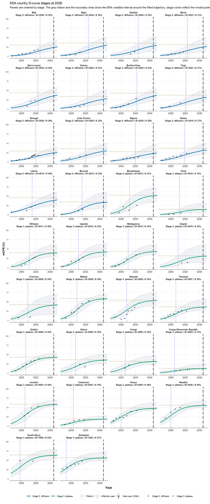

```r
ggplot(ssa_stage_country_plot, aes(x = year, y = 100 * p_mean)) +
  geom_ribbon(
    aes(
      ymin = 100 * p_p05,
      ymax = 100 * p_p95
    ),
    fill = "#CBD5E1",
    alpha = 0.30
  ) +
  geom_line(
    aes(
      y = 100 * p_p05,
      group = stage_panel_label
    ),
    color = "#94A3B8",
    linewidth = 0.28,
    alpha = 0.95
  ) +
  geom_line(
    aes(
      y = 100 * p_p95,
      group = stage_panel_label
    ),
    color = "#94A3B8",
    linewidth = 0.28,
    alpha = 0.95
  ) +
  geom_line(
    aes(color = s_curve_stage_2026),
    linewidth = 0.94
  ) +
  geom_point(
    data = ssa_stage_country_obs,
    aes(x = year, y = mcp_pct),
    inherit.aes = FALSE,
    color = "black",
    size = 1.3,
    alpha = 0.68
  ) +
  geom_point(
    data = ssa_stage_country_meta,
    aes(x = 2026, y = 100 * p2026_mean, fill = s_curve_stage_2026),
    inherit.aes = FALSE,
    shape = 21,
    size = 1.9,
    stroke = 0.25,
    color = "white"
  ) +
  geom_hline(
    data = ssa_stage_country_meta,
    aes(yintercept = 100 * K_mean, linetype = "Fitted K"),
    color = "#8A5A00",
    linewidth = 0.72,
    alpha = 0.95
  ) +
  geom_vline(
    data = ssa_stage_country_meta,
    aes(xintercept = t0_year_mean, linetype = "Inflection year"),
    color = "#1D4ED8",
    linewidth = 0.74,
    alpha = 0.98
  ) +
  geom_vline(
    data = tibble(goal_year = ssa_goal_final_target_year, line_key = paste0("Goal year (", ssa_goal_final_target_year, ")")),
    aes(xintercept = goal_year, linetype = line_key),
    color = "grey15",
    linewidth = 0.8,
    alpha = 0.98
  ) +
  facet_wrap(~ stage_panel_label, ncol = 4, scales = "free_x") +
  scale_color_manual(values = ssa_stage_cols, name = "Stage at 2026") +
  scale_fill_manual(values = ssa_stage_cols, name = "Stage at 2026") +
  scale_linetype_manual(
    name = "Reference lines",
    values = setNames(
      c("dotted", "dotted", "longdash"),
      c(
        "Fitted K",
        "Inflection year",
        paste0("Goal year (", ssa_goal_final_target_year, ")")
      )
    ),
    breaks = c("Fitted K", "Inflection year", paste0("Goal year (", ssa_goal_final_target_year, ")"))
  ) +
  scale_x_continuous(
    breaks = function(x) {
      brks <- pretty(x, n = 4)
      brks[brks != ssa_goal_final_target_year]
    },
    expand = expansion(mult = c(0.02, 0.02))
  ) +
  coord_cartesian(ylim = c(0, 100), clip = "off") +
  theme_minimal(base_size = 9.4) +
  theme(
    legend.position = "bottom",
    legend.title = element_blank(),
    panel.grid.minor = element_blank(),
    panel.grid.major.x = element_line(color = "grey88", linewidth = 0.3),
    axis.line.x = element_line(color = "grey25", linewidth = 0.45),
    axis.ticks.x = element_line(color = "grey25", linewidth = 0.4),
    strip.text = element_text(face = "bold", size = 7.5, lineheight = 0.95),
    axis.text.x = element_text(size = 8.4, color = "grey15"),
    axis.text.y = element_text(size = 6.5, color = "grey15"),
    axis.title.x = element_text(face = "bold", size = 10.8, margin = margin(t = 7)),
    axis.title.y = element_text(face = "bold", size = 9.4),
    plot.margin = margin(6, 8, 14, 8)
  ) +
  guides(
    color = guide_legend(
      order = 1,
      override.aes = list(linewidth = 1.05, alpha = 1)
    ),
    linetype = guide_legend(
      order = 2,
      override.aes = list(
        color = c("#8A5A00", "#1D4ED8", "grey15"),
        linewidth = c(0.72, 0.74, 0.8)
      )
    )
  ) +
  labs(
    title = "SSA country S-curve stages at 2026",
    subtitle = paste0("Panels are ordered by stage. The grey ribbon and thin boundary lines show the 95% credible interval around the fitted trajectory, stage colors reflect the modal posterior stage at 2026, and the reference-line legend distinguishes fitted K, the inflection year, and the ", ssa_goal_final_target_year, " goal year."),
    x = "Year",
    y = "mCPR (%)"
  )
```

### 24.22.6 Focused S-curve subset: SSA weighted, priority weighted, and the 7 priority countries

This companion view keeps the most decision-relevant subset together in one place: a) the weighted SSA regional curve; b) the weighted priority-geographies curve; c) the seven priority countries individually.

The dark point now consistently marks the **estimated mCPR(2025)** in every panel. The two weighted panels keep their weighted stage summaries at `2025`; the country panels keep the same country-level stage classification used above.

```r
ssa_stage_focus_weighted_meta <- bind_rows(
  ssa_region_stage_summary %>%
    transmute(
      geography = "Sub-Saharan Africa (weighted)",
      display_order = 1,
      stage_group = s_curve_stage_2025,
      K_mean,
      t0_year_mean = inflection_year_p50,
      current_year = 2025,
      current_p_mean = p_2025_mean,
      stage_panel_label = paste0(
        "SSA weighted\n",
        s_curve_stage_2025,
        " | inflection~",
        round(inflection_year_p50),
        " | K ",
        round(100 * K_mean),
        "%"
      )
    ),
  ssa_priority_stage_summary %>%
    transmute(
      geography = ssa_goal_final_priority_label,
      display_order = 2,
      stage_group = s_curve_stage_2025,
      K_mean,
      t0_year_mean = inflection_year_p50,
      current_year = 2025,
      current_p_mean = p_2025_mean,
      stage_panel_label = paste0(
        "Priority weighted\n",
        s_curve_stage_2025,
        " | inflection~",
        round(inflection_year_p50),
        " | K ",
        round(100 * K_mean),
        "%"
      )
    )
)

ssa_stage_focus_country_meta <- ssa_stage_country_meta %>%
  filter(country %in% ssa_goal_final_priority_geographies) %>%
  left_join(
    ssa_goal_final_country_rows %>%
      transmute(geography = geography, current_p2025_mean = current_p2025_pct / 100),
    by = c("country" = "geography")
  ) %>%
  transmute(
    geography = country,
    display_order = match(country, ssa_goal_final_priority_geographies) + 2,
    stage_group = s_curve_stage_2026,
    K_mean,
    t0_year_mean,
    current_year = 2025,
    current_p_mean = current_p2025_mean,
    stage_panel_label = paste0(
      country,
      "\n",
      s_curve_stage_2026,
      " | t0~",
      round(t0_year_mean),
      " | K ",
      round(100 * K_mean),
      "%"
    )
  )

ssa_stage_focus_meta <- bind_rows(
  ssa_stage_focus_weighted_meta,
  ssa_stage_focus_country_meta
) %>%
  arrange(display_order) %>%
  mutate(
    stage_panel_label = factor(
      stage_panel_label,
      levels = stage_panel_label,
      ordered = TRUE
    )
  )

ssa_stage_focus_plot <- bind_rows(
  ssa_region_stage_plot %>%
    mutate(geography = "Sub-Saharan Africa (weighted)"),
  ssa_priority_stage_plot %>%
    mutate(geography = ssa_goal_final_priority_label),
  ssa_goal_final_traj_country %>%
    filter(geography %in% ssa_goal_final_priority_geographies)
) %>%
  left_join(
    ssa_stage_focus_meta %>%
      select(geography, stage_group, stage_panel_label),
    by = "geography"
  )

ssa_stage_focus_obs <- bind_rows(
  ssa_observed_weighted %>%
    transmute(
      geography = "Sub-Saharan Africa (weighted)",
      year,
      mcp_pct = 100 * observed_weighted_mcpr
    ),
  ssa_goal_final_priority_observed_weighted %>%
    transmute(
      geography = ssa_goal_final_priority_label,
      year,
      mcp_pct = 100 * observed_weighted_mcpr
    ),
  mcpr_logistic_data %>%
    filter(country %in% ssa_goal_final_priority_geographies) %>%
    transmute(
      geography = country,
      year,
      mcp_pct = 100 * mCPR
    )
) %>%
  left_join(
    ssa_stage_focus_meta %>% select(geography, stage_panel_label),
    by = "geography"
  )
```

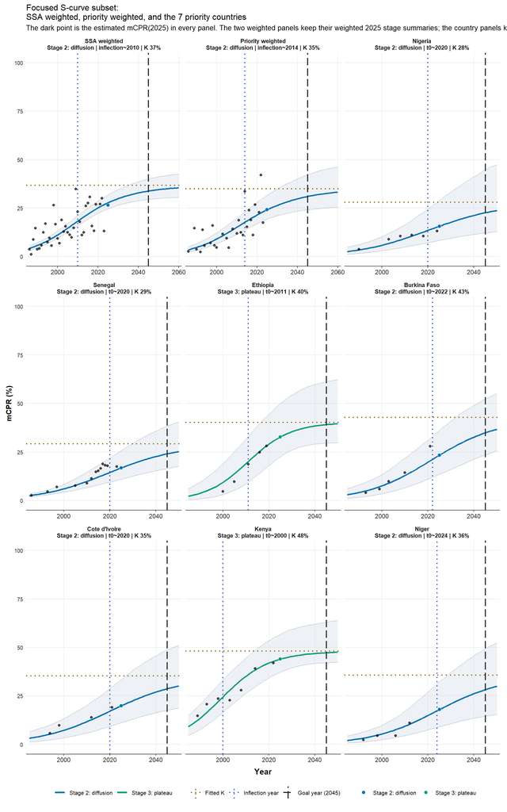

```r
ggplot(ssa_stage_focus_plot, aes(x = year, y = 100 * p_mean)) +
  geom_ribbon(
    aes(
      ymin = 100 * p_p05,
      ymax = 100 * p_p95
    ),
    fill = "#CBD5E1",
    alpha = 0.32
  ) +
  geom_line(
    aes(
      y = 100 * p_p05,
      group = stage_panel_label
    ),
    color = "#94A3B8",
    linewidth = 0.30,
    alpha = 0.95
  ) +
  geom_line(
    aes(
      y = 100 * p_p95,
      group = stage_panel_label
    ),
    color = "#94A3B8",
    linewidth = 0.30,
    alpha = 0.95
  ) +
  geom_line(
    aes(color = stage_group),
    linewidth = 1.0
  ) +
  geom_point(
    data = ssa_stage_focus_obs,
    aes(x = year, y = mcp_pct),
    inherit.aes = FALSE,
    color = "black",
    size = 1.35,
    alpha = 0.68
  ) +
  geom_point(
    data = ssa_stage_focus_meta,
    aes(x = current_year, y = 100 * current_p_mean, fill = stage_group),
    inherit.aes = FALSE,
    shape = 21,
    size = 2.2,
    stroke = 0.28,
    color = "white"
  ) +
  geom_hline(
    data = ssa_stage_focus_meta,
    aes(yintercept = 100 * K_mean, linetype = "Fitted K"),
    color = "#8A5A00",
    linewidth = 0.78,
    alpha = 0.98
  ) +
  geom_vline(
    data = ssa_stage_focus_meta,
    aes(xintercept = t0_year_mean, linetype = "Inflection year"),
    color = "#1D4ED8",
    linewidth = 0.78,
    alpha = 0.98
  ) +
  geom_vline(
    data = tibble(goal_year = ssa_goal_final_target_year, line_key = paste0("Goal year (", ssa_goal_final_target_year, ")")),
    aes(xintercept = goal_year, linetype = line_key),
    color = "grey15",
    linewidth = 0.82,
    alpha = 0.98
  ) +
  facet_wrap(~ stage_panel_label, ncol = 3, scales = "free_x") +
  scale_color_manual(values = ssa_stage_cols, name = "Stage label") +
  scale_fill_manual(values = ssa_stage_cols, name = "Stage label") +
  scale_linetype_manual(
    name = "Reference lines",
    values = setNames(
      c("dotted", "dotted", "longdash"),
      c(
        "Fitted K",
        "Inflection year",
        paste0("Goal year (", ssa_goal_final_target_year, ")")
      )
    ),
    breaks = c("Fitted K", "Inflection year", paste0("Goal year (", ssa_goal_final_target_year, ")"))
  ) +
  scale_x_continuous(
    breaks = function(x) {
      brks <- pretty(x, n = 4)
      brks[brks != ssa_goal_final_target_year]
    },
    expand = expansion(mult = c(0.02, 0.02))
  ) +
  coord_cartesian(ylim = c(0, 100), clip = "off") +
  theme_minimal(base_size = 10.0) +
  theme(
    legend.position = "bottom",
    legend.title = element_blank(),
    panel.grid.minor = element_blank(),
    panel.grid.major.x = element_line(color = "grey88", linewidth = 0.3),
    axis.line.x = element_line(color = "grey25", linewidth = 0.45),
    axis.ticks.x = element_line(color = "grey25", linewidth = 0.4),
    strip.text = element_text(face = "bold", size = 8.2, lineheight = 0.96),
    axis.text.x = element_text(size = 8.9, color = "grey15"),
    axis.text.y = element_text(size = 7.4, color = "grey15"),
    axis.title.x = element_text(face = "bold", size = 11.2, margin = margin(t = 7)),
    axis.title.y = element_text(face = "bold", size = 10.4),
    plot.margin = margin(6, 10, 14, 8)
  ) +
  guides(
    color = guide_legend(
      order = 1,
      override.aes = list(linewidth = 1.08, alpha = 1)
    ),
    linetype = guide_legend(
      order = 2,
      override.aes = list(
        color = c("#8A5A00", "#1D4ED8", "grey15"),
        linewidth = c(0.78, 0.78, 0.82)
      )
    )
  ) +
  labs(
    title = "Focused S-curve subset:\nSSA weighted, priority weighted, and the 7 priority countries",
    subtitle = "The dark point is the estimated mCPR(2025) in every panel. The two weighted panels keep their weighted 2025 stage summaries; the country panels keep the same country-stage labeling used above.",
    x = "Year",
    y = "mCPR (%)"
  )
```

## 24.23 Global posterior predicted trajectory

Technical note: a) A recurring failure mode in this project was `predictor_fe(...)` in global prediction when region-level `newdata` was built from external templates that did not perfectly align with the fitted factor structure. b) This chunk builds region rows from the fitted DHS data itself and checks `region_prior`, `s_region_fixed`, and region weights before prediction.

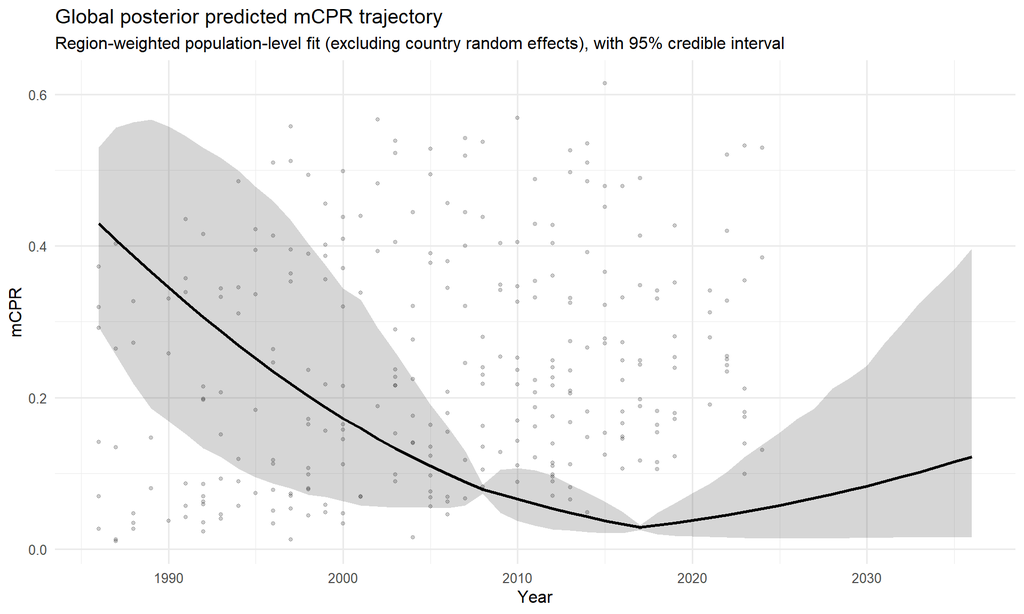

```r
# Compute and plot global posterior trajectory with 95% credible interval.
year_grid_global <- seq(min(mcpr_logistic_data$year, na.rm = TRUE), 2036, by = 1)

# Build a population-level grid by region and year, then aggregate with region weights.
# IMPORTANT:
# For nonlinear brms prediction, `newdata` must carry predictor columns with the same
# classes/levels as the fitted model design matrix. We build from mcpr_logistic_data
# directly to avoid `predictor_fe` errors from mismatched factor levels or missing joins.
region_profile <- mcpr_logistic_data %>%
  distinct(region_prior, s_region_fixed) %>%
  filter(!is.na(region_prior), !is.na(s_region_fixed)) %>%
  mutate(region_prior = as.character(region_prior)) %>%
  arrange(region_prior)

region_weights <- mcpr_logistic_data %>%
  distinct(country, region_prior) %>%
  mutate(region_prior = as.character(region_prior)) %>%
  count(region_prior, name = "n_country") %>%
  inner_join(region_profile %>% select(region_prior), by = "region_prior") %>%
  mutate(weight = n_country / sum(n_country))

nd_global <- tidyr::crossing(
  region_profile,
  year = year_grid_global
) %>%
  mutate(
    region_prior = as.character(region_prior),
    country = as.character(mcpr_logistic_data$country[1]),
    year_center = year - 2000,
    n = 1L,
    y = 0L
  ) %>%
  left_join(region_weights %>% select(region_prior, weight), by = "region_prior")

if (any(is.na(nd_global$region_prior))) {
  stop("nd_global contains NA region_prior; cannot run posterior prediction.")
}
if (any(is.na(nd_global$s_region_fixed))) {
  stop("nd_global contains NA s_region_fixed; cannot run posterior prediction.")
}
if (any(is.na(nd_global$weight))) {
  stop("nd_global contains NA region weights; cannot run global aggregation.")
}

ep_global_region <- posterior_epred(fit_logistic, newdata = nd_global, re_formula = NA)

# Weighted average over region-specific fitted curves for each posterior draw and year.
ep_global <- sapply(year_grid_global, function(yy) {
  idx <- which(nd_global$year == yy)
  ep_global_region[, idx, drop = FALSE] %*% nd_global$weight[idx]
})

global_curve <- tibble(
  year = year_grid_global,
  p_mean = colMeans(ep_global),
  p_lo = apply(ep_global, 2, quantile, ci_lower),
  p_hi = apply(ep_global, 2, quantile, ci_upper)
)

obs_all <- mcpr_logistic_data %>% select(year, mCPR)

ggplot() +
  geom_point(data = obs_all, aes(x = year, y = mCPR), alpha = 0.20, size = 1) +
  geom_ribbon(data = global_curve, aes(x = year, ymin = p_lo, ymax = p_hi), alpha = 0.20) +
  geom_line(data = global_curve, aes(x = year, y = p_mean), linewidth = 1) +
  theme_minimal(base_size = 12) +
  labs(
    title = "Global posterior predicted mCPR trajectory",
    subtitle = "Region-weighted population-level fit (excluding country random effects), with 95% credible interval",
    x = "Year",
    y = "mCPR"
  )
```

## 24.24 Implied growth and acceleration (global posterior)

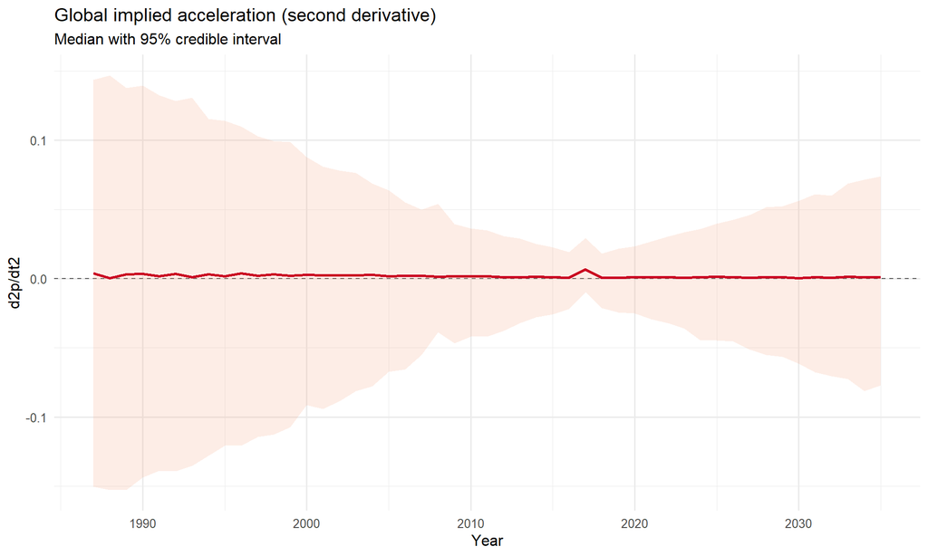

```r
# Derive and plot first/second derivatives with posterior uncertainty bands.
global_curve_deriv <- global_curve %>%
  arrange(year) %>%
  mutate(
    dp_dt = (lead(p_mean) - lag(p_mean)) / (lead(year) - lag(year)),
    d2p_dt2 = (lead(p_mean) - 2 * p_mean + lag(p_mean)) / (((lead(year) - lag(year)) / 2)^2)
  )

# ep_global has dimensions: draws x years (created in global-posterior-predicted chunk).
n_year <- ncol(ep_global)
if (n_year >= 3) {
  # Central-difference derivatives by posterior draw.
  dp_draws <- sapply(2:(n_year - 1), function(j) {
    (ep_global[, j + 1] - ep_global[, j - 1]) / (year_grid_global[j + 1] - year_grid_global[j - 1])
  })

  d2p_draws <- sapply(2:(n_year - 1), function(j) {
    (ep_global[, j + 1] - 2 * ep_global[, j] + ep_global[, j - 1]) /
      (((year_grid_global[j + 1] - year_grid_global[j - 1]) / 2)^2)
  })

  deriv_ci <- tibble(
    year = year_grid_global[2:(n_year - 1)],
    dp_p05 = apply(dp_draws, 2, quantile, probs = ci_lower, na.rm = TRUE),
    dp_p50 = apply(dp_draws, 2, quantile, probs = 0.50, na.rm = TRUE),
    dp_p95 = apply(dp_draws, 2, quantile, probs = ci_upper, na.rm = TRUE),
    d2p_p05 = apply(d2p_draws, 2, quantile, probs = ci_lower, na.rm = TRUE),
    d2p_p50 = apply(d2p_draws, 2, quantile, probs = 0.50, na.rm = TRUE),
    d2p_p95 = apply(d2p_draws, 2, quantile, probs = ci_upper, na.rm = TRUE)
  )

  ggplot(deriv_ci, aes(x = year, y = dp_p50)) +
    geom_hline(yintercept = 0, linetype = "dashed", alpha = 0.6) +
    geom_ribbon(aes(ymin = dp_p05, ymax = dp_p95), alpha = 0.20, fill = "#6BAED6") +
    geom_line(linewidth = 1, color = "#2171B5") +
    theme_minimal(base_size = 12) +
    labs(
      title = "Global implied growth rate (first derivative)",
      subtitle = "Median with 95% credible interval",
      x = "Year",
      y = "dp/dt"
    )

  ggplot(deriv_ci, aes(x = year, y = d2p_p50)) +
    geom_hline(yintercept = 0, linetype = "dashed", alpha = 0.6) +
    geom_ribbon(aes(ymin = d2p_p05, ymax = d2p_p95), alpha = 0.20, fill = "#F4A582") +
    geom_line(linewidth = 1, color = "#CA0020") +
    theme_minimal(base_size = 12) +
    labs(
      title = "Global implied acceleration (second derivative)",
      subtitle = "Median with 95% credible interval",
      x = "Year",
      y = "d2p/dt2"
    )
}
```

# 25 Exploratory regional check: latest observed mCPR by region

This exploratory section aggregates each country’s most recent observed mCPR and compares the distribution across the eight analytic regions.

```r
# Keep one row per country: the latest non-missing observed survey value.
latest_country_obs <- mcpr_logistic_data %>%
  filter(!is.na(mCPR), !is.na(year)) %>%
  group_by(country, region) %>%
  slice_max(order_by = year, n = 1, with_ties = FALSE) %>%
  ungroup() %>%
  select(country, region, last_year = year, last_mcpr = mCPR)

# Summarize latest country values within each region.
latest_region_summary <- latest_country_obs %>%
  group_by(region) %>%
  summarise(
    n_countries = n(),
    mean_last_mcpr = mean(last_mcpr, na.rm = TRUE),
    median_last_mcpr = median(last_mcpr, na.rm = TRUE),
    p25_last_mcpr = quantile(last_mcpr, 0.25, na.rm = TRUE),
    p75_last_mcpr = quantile(last_mcpr, 0.75, na.rm = TRUE),
    min_last_mcpr = min(last_mcpr, na.rm = TRUE),
    max_last_mcpr = max(last_mcpr, na.rm = TRUE),
    .groups = "drop"
  ) %>%
  arrange(region)

knitr::kable(
  latest_region_summary %>%
    mutate(across(where(is.numeric), ~ round(.x, 4))),
  caption = "Latest observed country mCPR by region (country-last observation summary)"
)
```

Latest observed country mCPR by region (country-last observation summary)

| region | n_countries | mean_last_mcpr | median_last_mcpr | p25_last_mcpr | p75_last_mcpr | min_last_mcpr | max_last_mcpr |
| --- | --- | --- | --- | --- | --- | --- | --- |
| Central Africa | 5 | 0.1411 | 0.1638 | 0.0989 | 0.1713 | 0.0484 | 0.2229 |
| East Asia and Pacific | 5 | 0.3366 | 0.3119 | 0.2426 | 0.4136 | 0.1481 | 0.5668 |
| East/Southern Africa | 16 | 0.3409 | 0.3461 | 0.2533 | 0.4788 | 0.0985 | 0.5322 |
| Europe and Central Asia | 6 | 0.2275 | 0.2193 | 0.1890 | 0.3043 | 0.0281 | 0.3867 |
| Latin America and Carribbean | 9 | 0.4071 | 0.4292 | 0.3221 | 0.5101 | 0.2226 | 0.6144 |
| Middle East and North Africa | 4 | 0.3633 | 0.3221 | 0.2860 | 0.3993 | 0.2741 | 0.5348 |
| South Asia | 5 | 0.3250 | 0.3275 | 0.2435 | 0.4267 | 0.1064 | 0.5207 |
| West Africa | 13 | 0.1779 | 0.1745 | 0.1223 | 0.2344 | 0.1099 | 0.2794 |

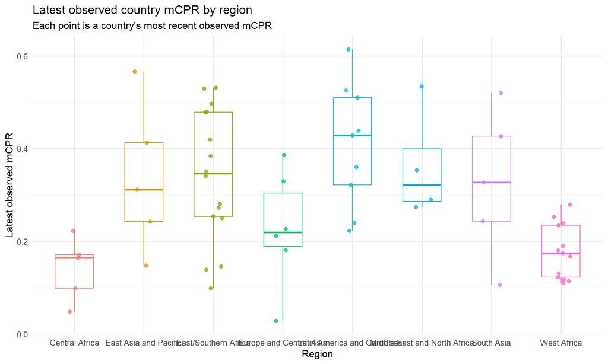

```r
# Visualize region-level spread of latest observed country values.
ggplot(latest_country_obs, aes(x = factor(region, levels = sort(unique(region))), y = last_mcpr, color = region)) +
  geom_boxplot(outlier.shape = NA, alpha = 0.12, width = 0.55) +
  geom_jitter(width = 0.15, alpha = 0.75, size = 2) +
  theme_minimal(base_size = 12) +
  theme(legend.position = "none") +
  labs(
    title = "Latest observed country mCPR by region",
    subtitle = "Each point is a country's most recent observed mCPR",
    x = "Region",
    y = "Latest observed mCPR"
  )
```

# 26 Model selection

This section explains **why this report carries forward the FPET best-compromise model** rather than the production fixed-$s$ benchmark, the region-fixed-$K$ benchmark, or the baseline FPET specification.

We compared four model families on the **same 30-country holdout design**:

1. `Fixed s, country K`: the production benchmark with region-fixed speed and country-varying ceiling.
2. `Fixed K, country s`: the alternative benchmark with region-fixed ceiling and country-varying speed.
3. `FPET baseline`: the hierarchical logistic + AR(1) model with country-varying $K$ and $s$ under stronger persistence.
4. `FPET best compromise`: the same FPET hierarchy, but with slightly lower AR persistence and a somewhat more flexible historical deviation so country curves can follow observed histories more closely without giving up the global/regional structure that identifies $K$ and $s$.

The selection goal was not just “small point error.” We wanted a model that:

1. predicts held-out last observations well;
2. gives intervals that are informative rather than mechanically huge or unrealistically tight;
3. converges cleanly enough to trust the posterior.

```r
holdout_results_dir <- file.path(root_dir, "holdout_model_comparison_30")
holdout_summary_by_method <- read.csv(file.path(holdout_results_dir, "holdout_summary_by_method.csv"))
holdout_sampling_diagnostics <- read.csv(file.path(holdout_results_dir, "holdout_sampling_diagnostics.csv"))
holdout_friedman_tests <- read.csv(file.path(holdout_results_dir, "holdout_friedman_tests.csv"))
holdout_pairwise_wilcoxon_tests <- read.csv(file.path(holdout_results_dir, "holdout_pairwise_wilcoxon_tests.csv"))
holdout_interval_decomp <- read.csv(file.path(holdout_results_dir, "holdout_interval_score_decomposition.csv"))

method_lookup <- tibble::tribble(
  ~method, ~description,
  "Fixed s, country K", "Production benchmark: region-fixed speed, country-varying ceiling K.",
  "Fixed K, country s", "Alternative benchmark: region-fixed ceiling K, country-varying speed s.",
  "FPET baseline", "Hierarchical logistic + AR(1) deviation with country-varying K and s under stronger region-informed persistence.",
  "FPET best compromise", "Selected FPET variant: same hierarchical structure, but lower AR persistence and slightly more flexible historical deviation."
)

knitr::kable(method_lookup, caption = "Models compared in the 30-country holdout study")
```

Models compared in the 30-country holdout study

| method | description |
| --- | --- |
| Fixed s, country K | Production benchmark: region-fixed speed, country-varying ceiling K. |
| Fixed K, country s | Alternative benchmark: region-fixed ceiling K, country-varying speed s. |
| FPET baseline | Hierarchical logistic + AR(1) deviation with country-varying K and s under stronger region-informed persistence. |
| FPET best compromise | Selected FPET variant: same hierarchical structure, but lower AR persistence and slightly more flexible historical deviation. |

## 26.1 Holdout metrics

The table below reports the main quantities we used:

1. **MAE** and **RMSE** summarize point-prediction error on the held-out last survey.
2. **90% interval score** rewards intervals that are both informative and well calibrated.
3. **Coverage** is shown only as context, because a model can inflate coverage by making intervals excessively wide.
4. **Rhat**, **ESS**, and **divergences** tell us whether the sampler itself was behaving well enough to trust the posterior summaries.

```r
holdout_summary_display <- holdout_summary_by_method %>%
  transmute(
    method,
    `MAE (pp)` = 100 * MAE,
    `RMSE (pp)` = 100 * RMSE,
    `90% interval score (pp)` = 100 * mean_interval_score,
    `Mean 90% width (pp)` = 100 * mean_interval_width,
    `Coverage (%)` = 100 * coverage_90,
    `Max Rhat` = max_rhat,
    `Params with Rhat > 1.01` = n_rhat_gt_101,
    `Params with Rhat > 1.05` = n_rhat_gt_105,
    `Divergences` = divergences,
    `Min ESS bulk` = min_ess_bulk
  ) %>%
  mutate(across(where(is.numeric), ~ round(.x, 2)))

knitr::kable(
  holdout_summary_display,
  caption = "30-country last-observation holdout comparison across model families"
)
```

30-country last-observation holdout comparison across model families

| method | MAE (pp) | RMSE (pp) | 90% interval score (pp) | Mean 90% width (pp) | Coverage (%) | Max Rhat | Params with Rhat > 1.01 | Params with Rhat > 1.05 | Divergences | Min ESS bulk |
| --- | --- | --- | --- | --- | --- | --- | --- | --- | --- | --- |
| Fixed s, country K | 3.75 | 5.22 | 60.58 | 1.61 | 6.67 | 1.10 | 82 | 12 | 0 | 37.72 |
| Fixed K, country s | 4.31 | 5.58 | 77.73 | 1.03 | 10.00 | 1.35 | 120 | 82 | 78 | 5.78 |
| FPET baseline | 2.64 | 3.23 | 16.35 | 14.80 | 93.33 | 1.02 | 22 | 0 | 0 | 236.87 |
| FPET best compromise | 2.69 | 3.30 | 17.09 | 15.14 | 93.33 | 1.02 | 7 | 0 | 0 | 171.28 |

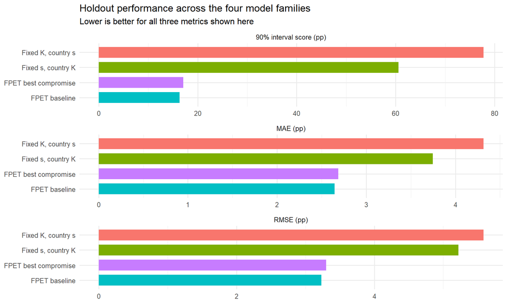

```r
holdout_metric_plot_tbl <- holdout_summary_by_method %>%
  transmute(
    method,
    `MAE (pp)` = 100 * MAE,
    `RMSE (pp)` = 100 * RMSE,
    `90% interval score (pp)` = 100 * mean_interval_score
  ) %>%
  pivot_longer(cols = -method, names_to = "metric", values_to = "value")

ggplot(holdout_metric_plot_tbl, aes(x = reorder(method, value), y = value, fill = method)) +
  geom_col(width = 0.72, show.legend = FALSE) +
  facet_wrap(~ metric, scales = "free_x", ncol = 1) +
  coord_flip() +
  theme_minimal(base_size = 12) +
  labs(
    title = "Holdout performance across the four model families",
    subtitle = "Lower is better for all three metrics shown here",
    x = NULL,
    y = NULL
  )
```

## 26.2 Why interval score matters

Coverage alone is not enough, because a model can get “good” coverage by making intervals extremely wide. The interval score solves that by combining:

$$\text{interval score} = \text{interval width} + \text{miss penalty}.$$

So:

1. a narrower interval is better **if it still contains the truth**;
2. an overconfident interval gets hit with a large miss penalty;
3. this is why interval score is more informative than raw coverage alone when comparing models with very different uncertainty widths.

```r
holdout_interval_decomp_display <- holdout_interval_decomp %>%
  transmute(
    method,
    `Mean width component (pp)` = 100 * mean_width_component,
    `Mean miss penalty (pp)` = 100 * mean_miss_penalty,
    `Mean interval score (pp)` = 100 * mean_interval_score,
    `Miss rate (%)` = 100 * miss_rate
  ) %>%
  mutate(across(where(is.numeric), ~ round(.x, 2)))

knitr::kable(
  holdout_interval_decomp_display,
  caption = "Decomposition of the 90% interval score into width and miss-penalty components"
)
```

Decomposition of the 90% interval score into width and miss-penalty components

| method | Mean width component (pp) | Mean miss penalty (pp) | Mean interval score (pp) | Miss rate (%) |
| --- | --- | --- | --- | --- |
| Fixed s, country K | 1.61 | 58.97 | 60.58 | 93.33 |
| Fixed K, country s | 1.03 | 76.70 | 77.73 | 90.00 |
| FPET baseline | 14.80 | 1.56 | 16.35 | 6.67 |
| FPET best compromise | 15.14 | 1.95 | 17.09 | 6.67 |

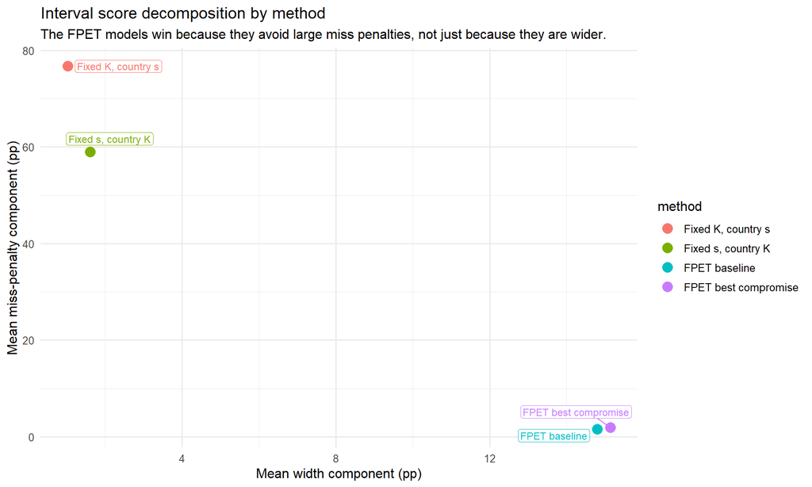

```r
ggplot(
  holdout_interval_decomp,
  aes(
    x = 100 * mean_width_component,
    y = 100 * mean_miss_penalty,
    color = method,
    label = method
  )
) +
  geom_point(size = 4) +
  ggrepel::geom_label_repel(
    size = 3.2,
    label.padding = grid::unit(0.15, "lines"),
    box.padding = 0.35,
    point.padding = 0.25,
    show.legend = FALSE,
    seed = 20260328
  ) +
  theme_minimal(base_size = 12) +
  labs(
    title = "Interval score decomposition by method",
    subtitle = "The FPET models win because they avoid large miss penalties, not just because they are wider.",
    x = "Mean width component (pp)",
    y = "Mean miss-penalty component (pp)"
  )
```

## 26.3 Statistical tests

We used two types of paired tests on the same 30 held-out country rows:

1. **Friedman tests** for an overall four-method comparison.
2. **Pairwise Wilcoxon signed-rank tests** with Holm correction for the head-to-head comparisons.

```r
knitr::kable(
  holdout_friedman_tests %>%
    mutate(across(where(is.numeric), ~ signif(.x, 4))),
  caption = "Friedman tests across all four methods"
)
```

Friedman tests across all four methods

| metric | statistic | p_value |
| --- | --- | --- |
| abs_error | 2.20 | 0.5319000 |
| sq_error | 2.20 | 0.5319000 |
| interval_score | 23.64 | 0.0000297 |

```r
knitr::kable(
  holdout_pairwise_wilcoxon_tests %>%
    mutate(across(where(is.numeric), ~ signif(.x, 4))),
  caption = "Pairwise Wilcoxon signed-rank tests with Holm correction"
)
```

Pairwise Wilcoxon signed-rank tests with Holm correction

| metric | method_a | method_b | p_value | median_diff_a_minus_b | p_holm |
| --- | --- | --- | --- | --- | --- |
| abs_error | Fixed s, country K | Fixed K, country s | 0.6216000 | -0.0057140 | 1.0000000 |
| abs_error | Fixed s, country K | FPET baseline | 0.0804100 | 0.0072660 | 0.3216000 |
| abs_error | Fixed s, country K | FPET best compromise | 0.0916800 | 0.0070120 | 0.3216000 |
| abs_error | Fixed K, country s | FPET baseline | 0.0114100 | 0.0073620 | 0.0684600 |
| abs_error | Fixed K, country s | FPET best compromise | 0.0377600 | 0.0062580 | 0.1888000 |
| abs_error | FPET baseline | FPET best compromise | 0.5928000 | 0.0000448 | 1.0000000 |
| sq_error | Fixed s, country K | Fixed K, country s | 0.5928000 | -0.0001647 | 1.0000000 |
| sq_error | Fixed s, country K | FPET baseline | 0.1086000 | 0.0001347 | 0.3361000 |
| sq_error | Fixed s, country K | FPET best compromise | 0.0840300 | 0.0001384 | 0.3361000 |
| sq_error | Fixed K, country s | FPET baseline | 0.0224300 | 0.0003866 | 0.1346000 |
| sq_error | Fixed K, country s | FPET best compromise | 0.0397000 | 0.0002300 | 0.1985000 |
| sq_error | FPET baseline | FPET best compromise | 0.6658000 | 0.0000002 | 1.0000000 |
| interval_score | Fixed s, country K | Fixed K, country s | 0.3547000 | -0.1184000 | 0.5334000 |
| interval_score | Fixed s, country K | FPET baseline | 0.0000784 | 0.2145000 | 0.0003138 |
| interval_score | Fixed s, country K | FPET best compromise | 0.0001199 | 0.2181000 | 0.0003598 |
| interval_score | Fixed K, country s | FPET baseline | 0.0000465 | 0.5021000 | 0.0002554 |
| interval_score | Fixed K, country s | FPET best compromise | 0.0000426 | 0.4890000 | 0.0002554 |
| interval_score | FPET baseline | FPET best compromise | 0.2667000 | -0.0032300 | 0.5334000 |

Interpretation of the test results:

1. For **MAE** and **RMSE**, the FPET models are numerically better, but the paired tests do not separate them strongly enough at this 30-country sample size to declare a clear winner on point error alone.
2. For **interval score**, the four-way Friedman test is clearly significant, and both FPET variants outperform both older logistic models after Holm correction.
3. Between the two FPET variants, the holdout errors are very similar, so the final choice comes down mainly to sampler quality and interpretability.

## 26.4 Selection decision

We therefore carry forward **FPET best compromise** as the final report model for three reasons:

1. it is essentially tied with FPET baseline on holdout point prediction;
2. it clearly dominates the two older logistic models on interval score, meaning it gives better-calibrated uncertainty once width is penalized;
3. it has the cleanest sampler behavior of the four in this benchmark, with zero divergences and fewer high-Rhat parameters than the other candidates.

So the bottom line is:

- `Fixed K, country s` is not competitive.
- `Fixed s, country K` remains useful as a constrained benchmark, but its holdout intervals are far too sharp for the masked last-survey task.
- `FPET baseline` predicts very well, but `FPET best compromise` gives nearly the same predictive performance with cleaner computation.
- That is why this report uses the **FPET best-compromise** fit.

# 27 Appendix

## 27.1 Appendix A: Modeling options tried and identifiability

We tested several candidate specifications before settling on the final model.

Options tried to date: a) **Production benchmark:** region-fixed $s$, country-varying $K$. This was computationally convenient, but it imposed stronger structure than we wanted once we moved to the FPET-style framework. b) **Region-fixed $K$, country-varying $s$:** this reduced one source of drift but compressed country headroom too aggressively and remained unstable. c) **FPET baseline:** country-varying $K_i$, $s_i$, and $t_{0,i}$ with a hierarchical AR(1) deviation process. This was the first version that made joint identification of $K$ and $s$ genuinely workable on our DHS data. d) **FPET best compromise:** same FPET structure, but with lower AR persistence and a slightly more flexible historical deviation process. This is the current final model. e) **Looser $s/t_0$ FPET sensitivity:** fit a bit more local history, but did not improve the predictive-vs-stability balance. f) **Loosest $K/s/t_0$ FPET sensitivity:** too unstable to recommend as a production choice.

The core issue across the rejected variants was the **identifiability tradeoff between $K$ and $s$**: with sparse or noisy country series, higher ceilings with slower speeds can fit almost as well as lower ceilings with faster speeds.

In practical terms: a) the older constrained models can look tighter because they are forcing more of the uncertainty out of the system; b) the FPET family makes the uncertainty wider, but it does so by modeling country heterogeneity and short-run deviations explicitly; c) the final choice was therefore based on the combination of holdout error, interval score, and convergence diagnostics rather than on visual tightness alone.

## 27.2 Appendix B: Phase Classification Sensitivity to Fixed-$s$ Values

This appendix checks whether phase rankings are robust when re-fitting fixed-speed models at several $s$ values.

```r
run_appendix_fixeds_sensitivity <- FALSE
fixed_s_grid <- c(6, 8, 10, 12)

summarise_fit_diag_appendix <- function(fit_obj, model_name, td_max = 15) {
  dsum <- posterior::summarise_draws(
    posterior::as_draws_df(fit_obj),
    "rhat", "ess_bulk", "ess_tail"
  )
  nuts <- nuts_params(fit_obj)
  td_vals <- nuts$Value[nuts$Parameter == "treedepth__"]
  tibble(
    model = model_name,
    n_rhat_gt_101 = sum(dsum$rhat > 1.01, na.rm = TRUE),
    n_rhat_gt_105 = sum(dsum$rhat > 1.05, na.rm = TRUE),
    min_ess_bulk = min(dsum$ess_bulk, na.rm = TRUE),
    min_ess_tail = min(dsum$ess_tail, na.rm = TRUE),
    divergences = sum(nuts$Parameter == "divergent__" & nuts$Value == 1),
    max_treedepth = max(td_vals),
    n_treedepth_at_max = sum(td_vals >= td_max)
  )
}

classify_investment_from_summary <- function(country_summary_df, pct_scaleup = 0.20, pct_maintain = 0.20) {
  df <- country_summary_df %>%
    mutate(
      room_abs = head_mean,
      room_rel = 1 - rel_mean,
      r_growth = dplyr::percent_rank(dpdt_mean),
      r_head = dplyr::percent_rank(room_abs),
      r_room = dplyr::percent_rank(room_rel),
      leverage_head = r_growth * r_head,
      leverage_rel = r_growth * r_room,
      leverage = 0.4 * leverage_head + 0.6 * leverage_rel
    )

  n_total <- nrow(df)
  n_scaleup <- max(5, round(pct_scaleup * n_total))
  n_maintain <- max(5, round(pct_maintain * n_total))

  scaleup_set <- df %>% arrange(desc(leverage)) %>% slice_head(n = n_scaleup) %>% pull(country)
  maintain_set <- df %>% arrange(leverage) %>% slice_head(n = n_maintain) %>% pull(country)

  df %>%
    mutate(
      phase = case_when(
        country %in% scaleup_set ~ "Scale-up",
        country %in% maintain_set ~ "Maintain / equity",
        TRUE ~ "Build / monitor"
      )
    ) %>%
    arrange(desc(leverage))
}
```

```r
logistic_fixeds_grid <- bf(
  y | trials(n) ~ inv_logit(Kraw) *
    inv_logit((year_center - (-34 + 69 * inv_logit(t0raw))) / s_fixed),
  Kraw ~ 0 + region_prior + (1 | country),
  t0raw ~ 0 + region_prior + (1 | country),
  nl = TRUE
)

priors_fixeds_grid <- c(
  k_region_priors_internal,
  t0_region_priors_internal,
  prior(exponential(6),   nlpar = "Kraw", class = "sd", group = "country"),
  prior(exponential(0.5), nlpar = "t0raw",   class = "sd", group = "country")
)

fixeds_fit_results <- list()
fixeds_diag_rows <- list()

if (run_appendix_fixeds_sensitivity) {
  for (s_val in fixed_s_grid) {
    fit_path_s <- if (s_val == 8) {
      paste0("fit_logistic_fullhierK_regionPriors_boundedT0_fixedS8_", run_profile_label, ".rds")
    } else {
      paste0("fit_logistic_fullhierK_regionPriors_boundedT0_fixedS", s_val, "_sensitivity_", run_profile_label, ".rds")
    }

    model_data_s <- mcpr_logistic_data %>%
      mutate(s_fixed = s_val)

    if (file.exists(fit_path_s)) {
      fit_s <- readRDS(fit_path_s)
    } else {
      fit_s <- brm(
        formula = logistic_fixeds_grid,
        data    = model_data_s,
        family  = binomial(link = "identity"),
        prior   = priors_fixeds_grid,
        chains  = 4,
        cores   = 4,
        iter    = appendix_fixeds_iter,
        warmup  = appendix_fixeds_warmup,
        seed    = 8000 + s_val,
        control = list(adapt_delta = 0.995, max_treedepth = 15)
      )
      saveRDS(fit_s, fit_path_s)
    }

    nd_country_s <- model_data_s %>%
      distinct(country, region_prior) %>%
      arrange(country) %>%
      mutate(year_center = 0, n = 1, y = 0, s_fixed = s_val)

    etaK_draws_s <- posterior_linpred(
      fit_s, nlpar = "Kraw", newdata = nd_country_s,
      re_formula = NULL, transform = FALSE, summary = FALSE
    )
    K_draws_s <- plogis(etaK_draws_s)

    t0_raw_draws_s <- posterior_linpred(
      fit_s, nlpar = "t0raw", newdata = nd_country_s,
      re_formula = NULL, transform = FALSE, summary = FALSE
    )
    t0_draws_s <- t0_lower + t0_span * plogis(t0_raw_draws_s)

    n_draws_s <- nrow(K_draws_s)
    n_countries_s <- ncol(K_draws_s)
    t_dec <- 2026 - 2000
    t_mat_s <- matrix(t_dec, nrow = n_draws_s, ncol = n_countries_s)
    s_mat_s <- matrix(s_val, nrow = n_draws_s, ncol = n_countries_s)

    z_mat_s <- exp(-(t_mat_s - t0_draws_s) / s_mat_s)
    p_mat_s <- K_draws_s / (1 + z_mat_s)
    dpdt_mat_s <- (K_draws_s / s_mat_s) * z_mat_s / (1 + z_mat_s)^2

    qcol <- function(x, p) apply(x, 2, quantile, probs = p)

    country_summary_s <- tibble(
      country = nd_country_s$country,
      decision_year = 2026,
      s_assumed = s_val,
      K_mean = colMeans(K_draws_s),
      p_mean = colMeans(p_mat_s),
      head_mean = colMeans(K_draws_s - p_mat_s),
      rel_mean = colMeans(p_mat_s / K_draws_s),
      dpdt_mean = colMeans(dpdt_mat_s),
      dpdt_p05 = qcol(dpdt_mat_s, ci_lower),
      dpdt_p95 = qcol(dpdt_mat_s, ci_upper)
    )

    investment_s <- classify_investment_from_summary(country_summary_s)

    fixeds_fit_results[[as.character(s_val)]] <- list(
      fit = fit_s,
      summary = country_summary_s,
      investment = investment_s
    )

    fixeds_diag_rows[[as.character(s_val)]] <- summarise_fit_diag_appendix(
      fit_s, paste0("Fixed s = ", s_val)
    )
  }

  fixeds_diag_tbl <- bind_rows(fixeds_diag_rows)
  knitr::kable(
    fixeds_diag_tbl %>% mutate(across(where(is.numeric), ~ round(.x, 3))),
    caption = "Appendix: convergence diagnostics across fixed-speed sensitivity fits"
  )
}
```

```r
if (run_appendix_fixeds_sensitivity && length(fixeds_fit_results) > 0) {
  final_rank <- investment_table %>%
    arrange(desc(leverage)) %>%
    mutate(rank_final = row_number()) %>%
    select(country, phase_final = phase, rank_final)

  fixeds_assignments <- bind_rows(
    lapply(names(fixeds_fit_results), function(s_chr) {
      fixeds_fit_results[[s_chr]]$investment %>%
        mutate(
          scenario = paste0("Fixed s=", s_chr),
          rank_s = row_number()
        ) %>%
        select(country, scenario, phase, rank_s, leverage, dpdt_mean, head_mean, room_rel)
    })
  )

  fixeds_stability_tbl <- bind_rows(
    lapply(names(fixeds_fit_results), function(s_chr) {
      inv <- fixeds_fit_results[[s_chr]]$investment %>%
        mutate(rank_s = row_number()) %>%
        select(country, phase_s = phase, rank_s)

      cmp <- final_rank %>%
        inner_join(inv, by = "country") %>%
        mutate(phase_changed = phase_final != phase_s)

      final_scale <- final_rank %>% filter(phase_final == "Scale-up") %>% pull(country)
      s_scale <- inv %>% filter(phase_s == "Scale-up") %>% pull(country)
      final_main <- final_rank %>% filter(phase_final == "Maintain / equity") %>% pull(country)
      s_main <- inv %>% filter(phase_s == "Maintain / equity") %>% pull(country)

      tibble(
        scenario = paste0("Fixed s=", s_chr),
        spearman_rank_corr = cor(cmp$rank_final, cmp$rank_s, method = "spearman"),
        mean_abs_rank_shift = mean(abs(cmp$rank_final - cmp$rank_s)),
        pct_phase_changed = mean(cmp$phase_changed) * 100,
        scaleup_jaccard = length(intersect(final_scale, s_scale)) / length(union(final_scale, s_scale)),
        maintain_jaccard = length(intersect(final_main, s_main)) / length(union(final_main, s_main))
      )
    })
  )

  knitr::kable(
    fixeds_stability_tbl %>% mutate(across(where(is.numeric), ~ round(.x, 3))),
    caption = "Appendix: phase and ranking stability of fixed-s models vs the final model"
  )

  phase_grid_plot <- bind_rows(
    investment_table %>% transmute(country, scenario = "Final model", phase),
    fixeds_assignments %>% transmute(country, scenario, phase)
  )

  country_order <- investment_table %>% arrange(desc(leverage)) %>% pull(country)

  ggplot(
    phase_grid_plot %>%
      mutate(
        country = factor(country, levels = rev(country_order)),
        phase = factor(phase, levels = c("Scale-up", "Build / monitor", "Maintain / equity")),
        scenario = factor(scenario, levels = c("Final model", paste0("Fixed s=", fixed_s_grid)))
      ),
    aes(x = scenario, y = country, fill = phase)
  ) +
    geom_tile(color = "white", linewidth = 0.15) +
    scale_fill_manual(values = c(
      "Scale-up" = "#4A80E8",
      "Build / monitor" = "#F06A6A",
      "Maintain / equity" = "#2DA44E"
    )) +
    theme_minimal(base_size = 11) +
    labs(
      title = "Appendix: phase assignment stability across speed assumptions",
      subtitle = "Country order follows final-model leverage ranking",
      x = "Scenario",
      y = "Country"
    )
}
```

## 27.3 Appendix C: Why We Keep $K$ Country-Level

This check isolates what happens if we replace country-specific ceilings with region-fixed ceilings while keeping final-model $t_0$ and $s$ posteriors.

```r
k_region_lookup <- wb_region_prior_inputs %>%
  transmute(
    region_prior,
    K_region_fixed = pmin(pmax(median_K, 0.05), 0.98)
  ) %>%
  select(region_prior, K_region_fixed)

country_region_tbl <- nd_country %>%
  select(country, region_prior) %>%
  left_join(k_region_lookup, by = "region_prior") %>%
  arrange(country)

if (!all(country_region_tbl$country == countries)) {
  stop("Country order mismatch in appendix K-fixed check.")
}

if (any(is.na(country_region_tbl$K_region_fixed))) {
  stop("Missing regional fixed-K values for one or more countries in appendix K-fixed check.")
}

# Replace country-varying K draws with region-fixed K values while keeping final-model t0 and s.
K_draws_region_fixed <- matrix(
  rep(country_region_tbl$K_region_fixed, each = nrow(t0_draws)),
  nrow = nrow(t0_draws)
)

t_dec <- 2026 - 2000
t_mat_final <- matrix(t_dec, nrow = nrow(t0_draws), ncol = ncol(t0_draws))
z_mat_kfixed <- exp(-(t_mat_final - t0_draws) / s_draws)
p_mat_kfixed <- K_draws_region_fixed / (1 + z_mat_kfixed)
dpdt_mat_kfixed <- (K_draws_region_fixed / s_draws) * z_mat_kfixed / (1 + z_mat_kfixed)^2

country_summary_kfixed <- tibble(
  country = country_region_tbl$country,
  decision_year = 2026,
  K_mean = colMeans(K_draws_region_fixed),
  p_mean = colMeans(p_mat_kfixed),
  head_mean = colMeans(K_draws_region_fixed - p_mat_kfixed),
  rel_mean = colMeans(p_mat_kfixed / K_draws_region_fixed),
  dpdt_mean = colMeans(dpdt_mat_kfixed)
)

investment_kfixed <- classify_investment_from_summary(country_summary_kfixed) %>%
  mutate(rank_kfixed = row_number()) %>%
  select(country, phase_kfixed = phase, rank_kfixed)

final_rank <- investment_table %>%
  arrange(desc(leverage)) %>%
  mutate(rank_final = row_number()) %>%
  select(country, phase_final = phase, rank_final)

cmp_kfixed <- final_rank %>%
  inner_join(investment_kfixed, by = "country") %>%
  mutate(phase_changed = phase_final != phase_kfixed)

final_scale <- final_rank %>% filter(phase_final == "Scale-up") %>% pull(country)
kfix_scale <- investment_kfixed %>% filter(phase_kfixed == "Scale-up") %>% pull(country)

kfixed_stability <- tibble(
  scenario = "Region-fixed K (holding final-model t0 and s)",
  spearman_rank_corr = cor(cmp_kfixed$rank_final, cmp_kfixed$rank_kfixed, method = "spearman"),
  mean_abs_rank_shift = mean(abs(cmp_kfixed$rank_final - cmp_kfixed$rank_kfixed)),
  pct_phase_changed = mean(cmp_kfixed$phase_changed) * 100,
  scaleup_jaccard = length(intersect(final_scale, kfix_scale)) / length(union(final_scale, kfix_scale))
)

knitr::kable(
  kfixed_stability %>% mutate(across(where(is.numeric), ~ round(.x, 3))),
  caption = "Appendix: sensitivity to fixing K by region"
)
```

Appendix: sensitivity to fixing K by region

| scenario | spearman_rank_corr | mean_abs_rank_shift | pct_phase_changed | scaleup_jaccard |
| --- | --- | --- | --- | --- |
| Region-fixed K (holding final-model t0 and s) | 0.932 | 4.762 | 15.873 | 0.733 |

```r
if (exists("fixeds_stability_tbl") && exists("kfixed_stability")) {
  fixeds_min_corr <- min(fixeds_stability_tbl$spearman_rank_corr, na.rm = TRUE)
  fixeds_max_phase_change <- max(fixeds_stability_tbl$pct_phase_changed, na.rm = TRUE)
  kfixed_corr <- kfixed_stability$spearman_rank_corr[1]
  kfixed_phase_change <- kfixed_stability$pct_phase_changed[1]

  cat(
    "Fixed-s sensitivity summary: minimum Spearman rank correlation vs the final model =",
    round(fixeds_min_corr, 3),
    "and maximum phase change rate =",
    round(fixeds_max_phase_change, 1), "%.\n"
  )
  cat(
    "K-fixed sensitivity summary: Spearman rank correlation vs the final model =",
    round(kfixed_corr, 3),
    "and phase change rate =",
    round(kfixed_phase_change, 1), "%.\n"
  )
}
```

Interpretation: a) If fixed-$s$ scenarios remain close to the final model (high rank correlation, low phase switching), phase rules are robust to reasonable speed assumptions. b) If region-fixed $K$ causes larger rank or phase movement, that supports keeping $K$ country-specific in the final model.

## 27.4 Appendix D: Bayesian Power (Assurance) for a New Survey

This appendix uses **assurance**: the probability that a future survey will meet a pre-specified posterior decision rule under the current model.

Decision rule in this check: a) target year: 2028 b) meaningful increase threshold: $\Delta = 0.03$ (3 percentage points) c) success rule: $\Pr(p_{2028} - p_{\text{last obs}} \ge \Delta \mid \text{new survey}) \ge 0.80$

Scope: a) this is a fast design-stage approximation using Beta-Binomial updating for the *new* survey proportion; b) a full operating-characteristic study would re-fit the full hierarchical model for each simulated dataset.

What this appendix is doing: a) For each selected country, it first takes the fitted final model and extracts the posterior distribution of that country’s projected mCPR in 2028. b) It treats those posterior draws as plausible “true” 2028 mCPR values under the current model. c) For each candidate new survey sample size ($n=500,1000,\dots,3000$), it repeatedly simulates what a new survey could observe if the true 2028 mCPR were one of those plausible values. d) After each simulated survey, it updates only the new-survey proportion with a simple Beta-Binomial posterior, rather than re-fitting the full hierarchical model. e) It then checks whether that simulated survey would be strong enough to conclude, with at least 80% posterior probability, that 2028 mCPR is at least 3 percentage points above the country’s latest observed mCPR. f) The reported assurance is the share of simulated surveys that meet that decision rule, so it answers: “if the current model is roughly right, how often would a new survey of size $n$ be persuasive enough?”

```r
# Toggle this section if you want to skip assurance calculations in fast reruns.
run_bayesian_assurance <- FALSE

if (run_bayesian_assurance) {
  set.seed(20260225)

  # Settings for the assurance scenario.
  assurance_year <- 2028
  delta_increase <- 0.03
  posterior_cut <- 0.80
  n_sim <- 2000
  n_grid <- c(500, 1000, 1500, 2000, 3000)
  assurance_countries <- c("Nigeria", "India", "Ethiopia", "Pakistan", "Kenya")

  available_countries <- sort(unique(mcpr_logistic_data$country))
  assurance_countries <- assurance_countries[assurance_countries %in% available_countries]
  if (length(assurance_countries) == 0) {
    stop("No requested assurance countries are present in mcpr_logistic_data.")
  }

  # Build prediction frame for country-specific p(year) at the assurance year.
  nd_assurance <- mcpr_logistic_data %>%
    distinct(country, region_prior, s_region_fixed) %>%
    filter(country %in% assurance_countries) %>%
    arrange(country) %>%
    mutate(
      country = as.character(country),
      region_prior = as.character(region_prior),
      year = assurance_year,
      year_center = assurance_year - 2000,
      n = 1L,
      y = 0L
    )

  # Posterior draws of country-specific p(assurance_year) from the fitted model.
  p_assurance_draws <- posterior_epred(
    fit_logistic,
    newdata = nd_assurance,
    re_formula = NULL
  )
  # `posterior_epred()` can return:
  # a) a vector for one newdata row,
  # b) a draws x observations matrix for one-response models,
  # c) a draws x observations x categories array in some families.
  # This block standardizes everything to a draws x observations matrix
  # without relying on dimension-specific slicing.
  assurance_dims <- dim(p_assurance_draws)
  if (is.null(assurance_dims)) {
    if (nrow(nd_assurance) != 1L) {
      stop("Unexpected one-dimensional posterior_epred output for multiple assurance rows.")
    }
    p_assurance_draws <- matrix(p_assurance_draws, ncol = 1L)
  } else {
    p_assurance_draws <- matrix(
      p_assurance_draws,
      nrow = assurance_dims[1],
      ncol = prod(assurance_dims[-1])
    )
  }

  if (ncol(p_assurance_draws) != nrow(nd_assurance)) {
    stop("Assurance prediction columns do not match assurance newdata rows.")
  }

  # Baseline is each country's latest observed mCPR.
  latest_obs_assurance <- mcpr_logistic_data %>%
    group_by(country) %>%
    slice_max(order_by = year, n = 1, with_ties = FALSE) %>%
    ungroup() %>%
    transmute(country, last_year = year, last_mcpr = mCPR) %>%
    filter(country %in% assurance_countries) %>%
    arrange(country)

  # Align baseline to prediction column order.
  latest_obs_assurance <- latest_obs_assurance %>%
    right_join(nd_assurance %>% select(country) %>% distinct() %>% arrange(country), by = "country")

  # Simulation-based assurance calculation.
  assurance_results <- bind_rows(
    lapply(seq_len(nrow(nd_assurance)), function(j) {
      country_j <- nd_assurance$country[j]
      p_draw_j <- as.numeric(p_assurance_draws[, j])
      p_draw_j <- pmin(pmax(p_draw_j, 0.001), 0.999)

      base_j <- latest_obs_assurance$last_mcpr[latest_obs_assurance$country == country_j][1]
      thresh_j <- pmin(base_j + delta_increase, 0.999)

      bind_rows(lapply(n_grid, function(n_new) {
        # Sample plausible truths from the current model and simulate a new survey.
        # This approximates many future surveys we might observe at sample size n_new.
        p_true <- sample(p_draw_j, size = n_sim, replace = TRUE)
        y_new <- rbinom(n_sim, size = n_new, prob = p_true)

        # Approximate posterior for new survey proportion: Beta(1,1) prior + Binomial likelihood.
        # This step asks: after seeing y_new out of n_new, how much posterior support
        # is there that true 2028 mCPR exceeds the target threshold?
        post_prob_success <- 1 - pbeta(thresh_j, y_new + 1, n_new - y_new + 1)
        decision_success <- post_prob_success >= posterior_cut

        tibble(
          country = country_j,
          n_new = n_new,
          last_year = latest_obs_assurance$last_year[latest_obs_assurance$country == country_j][1],
          last_mcpr = base_j,
          threshold_mcpr = thresh_j,
          assurance = mean(decision_success),
          median_post_prob = median(post_prob_success),
          p2028_model_median = median(p_draw_j)
        )
      }))
    })
  ) %>%
    arrange(country, n_new)

  knitr::kable(
    assurance_results %>%
      mutate(across(where(is.numeric), ~ round(.x, 3))),
    caption = "Appendix: Bayesian assurance for detecting a >=3pp increase by 2028"
  )

  ggplot(assurance_results, aes(x = n_new, y = assurance, color = country)) +
    geom_line(linewidth = 1) +
    geom_point(size = 2) +
    geom_hline(yintercept = 0.8, linetype = "dashed", color = "grey40") +
    coord_cartesian(ylim = c(0, 1)) +
    theme_minimal(base_size = 12) +
    labs(
      title = "Bayesian assurance vs new-survey sample size",
      subtitle = "Success rule: posterior Pr(>=3pp increase by 2028) >= 0.80",
      x = "New survey sample size (n)",
      y = "Assurance (probability decision rule is met)"
    )
}
```

## 27.5 Export

```r
write.csv(investment_table, "mcpr_investment_table_final_model.csv", row.names = FALSE)
write.csv(investment_table_lastobs, "mcpr_investment_table_lastobs_headroom.csv", row.names = FALSE)
write.csv(latest_projection_table, "mcpr_latest_observed_vs_projection.csv", row.names = FALSE)
write.csv(time_to_k_table, "mcpr_time_to_99pct_k.csv", row.names = FALSE)
write.csv(country_growth_rate_table, "mcpr_country_growth_rates_over_time.csv", row.names = FALSE)
write.csv(acceleration_table, "mcpr_acceleration_status_2026.csv", row.names = FALSE)
write.csv(s_curve_stage_table, "mcpr_s_curve_stage_classification.csv", row.names = FALSE)
write.csv(s_curve_stage_2026_table, "mcpr_s_curve_stage_classification_2026.csv", row.names = FALSE)
write.csv(ssa_target40_table, "mcpr_ssa_target40_summary.csv", row.names = FALSE)
write.csv(ssa_summary_table, "mcpr_ssa_planning_summary.csv", row.names = FALSE)
write.csv(ssa_obs_growth_intervals, "mcpr_ssa_observed_interval_growth.csv", row.names = FALSE)
write.csv(ssa_region_goals_summary, "mcpr_ssa_region_goals_summary.csv", row.names = FALSE)
write.csv(ssa_goals_country_table, "mcpr_ssa_country_goals_summary.csv", row.names = FALSE)
write.csv(ssa_regional_influence_table, "mcpr_ssa_regional_influence_summary.csv", row.names = FALSE)

if (exists("fixeds_stability_tbl")) {
  write.csv(fixeds_stability_tbl, "mcpr_final_model_fixeds_phase_stability.csv", row.names = FALSE)
}
if (exists("kfixed_stability")) {
  write.csv(kfixed_stability, "mcpr_final_model_kfixed_sensitivity.csv", row.names = FALSE)
}
```